# Team 7 - EPL Football Results (Tidyverse)

Author

Firdauz B K, Jit Lin, Jonathan, Xiang Hong, Celeste

## Load Libraries

```r
library(gt)
library(tidyverse)
library(readr)
```

## Import Dataset

```r
teams <- read_csv("dataset/epl_teams.csv")
results <- read_csv("dataset/epl_results.csv")
```

# Task 1: Converting EPL Football Results into a League Table

## 1.1 Generate a League Table from the EPL Results

### Processing the results data

```r
standings <- results %>%

  # Convert the dataframe from wide to long format
  pivot_longer(-home_team, names_to = "away_team", values_to = "score") %>%

  # Remove entries where the home team and away team are the same (diagonal entries)
  filter(home_team != away_team) %>%  # Remove diagonal entries

  # Separate the score into home goals and away goals, converting them to numeric
  separate(score, into = c("home_goals", "away_goals"), convert = TRUE) %>%

  # Calculate points for home and away teams based on match results
  mutate(
    home_points = case_when(
      home_goals > away_goals ~ 3,
      home_goals == away_goals ~ 1,
      TRUE ~ 0
    ),
    away_points = case_when(
      away_goals > home_goals ~ 3,
      home_goals == away_goals ~ 1,
      TRUE ~ 0
    )
  )
```

Pivoting Data: The data is pivoted from wide to long format using pivot_longer, making it easier to calculate statistics for home and away teams. This transformation simplifies the processing and makes the data structure more manageable for calculations.

Separating Scores: The scores are separated into home and away goals using separate, allowing for individual goal calculations. This step is crucial for accurately determining match outcomes and calculating points.

Case When: case_when is used to assign points based on match results. This method is clear and concise, handling multiple conditions efficiently and ensuring that points are correctly allocated for wins, draws, and losses.

### Calculate total statistics for each team

```r
total_stats <- standings %>%

  # Pivot the dataframe to have one row per team per match
  pivot_longer(
    cols = c(home_team, away_team),
    names_to = "home_away",
    values_to = "team"
  ) %>%

  # Calculate points, goals for, and goals against for each team
  mutate(
    points = if_else(home_away == "home_team", home_points, away_points),
    goals_for = if_else(home_away == "home_team", home_goals, away_goals),
    goals_against = if_else(home_away == "home_team", away_goals, home_goals)
  ) %>%

  # Group the data by team to calculate total stats
  group_by(team) %>%

  # Summarize the data to get total points, goals for, goals against, and goal difference for each team
  summarize(
    points = sum(points),
    goals_for = sum(goals_for),
    goals_against = sum(goals_against),
    goal_diff = goals_for - goals_against
  )
```

Summarizing Statistics: Grouping by team and summarizing statistics helps in calculating the total points, goals for, goals against, and goal difference. This aggregation provides a comprehensive view of each team’s performance throughout the season.

### Join with team names and create final standings

```r
final_standings <- total_stats %>%

  # Join total_stats with team names to get full team names
  left_join(teams, by = c("team" = "abbr")) %>%

  # Arrange the teams by points, goal difference, and goals scored in descending order
  arrange(desc(points), desc(goal_diff), desc(goals_for)) %>%

  # Create a rank column based on the ordering
  mutate(rank = row_number()) %>%

  # Select and rename the columns to match the desired output
  select(rank, team = name, points, goal_diff, goals_for)
```

### Display the result

```r
print(final_standings, n = 20)
```

```
# A tibble: 20 × 5
    rank team                    points goal_diff goals_for
   <int> <chr>                    <dbl>     <int>     <int>
 1     1 Liverpool                   99        52        85
 2     2 Manchester City             81        67       102
 3     3 Manchester United           66        30        66
 4     4 Chelsea                     66        15        69
 5     5 Leicester City              62        26        67
 6     6 Tottenham Hotspur           59        14        61
 7     7 Wolverhampton Wanderers     59        11        51
 8     8 Arsenal                     56         8        56
 9     9 Sheffield United            54         0        39
10    10 Burnley                     54        -7        43
11    11 Southampton                 52        -9        51
12    12 Everton                     49       -12        44
13    13 Newcastle United            44       -20        38
14    14 Crystal Palace              43       -19        31
15    15 Brighton & Hove Albion      41       -15        39
16    16 West Ham United             39       -13        49
17    17 Aston Villa                 35       -26        41
18    18 Bournemouth                 34       -25        40
19    19 Watford                     34       -28        36
20    20 Norwich City                21       -49        26
```

## 1.2 Improve Visualization Using `gt` Functions

```r
  # Create the gt table
league_table <- final_standings %>%
  gt() %>%

  # Add a title and subtitle to the table
  tab_header(
    title = md("EPL 2019-2020 League Table"),
    subtitle = "Final Standings"
  ) %>%
  cols_label(
    rank = "Rank",
    team = "Team",
    points = "Points",
    goal_diff = "Goal Difference",
    goals_for = "Goals For"
  ) %>%

  # Center align and bold the column labels
  tab_style(
    style = cell_text(
      align = "center",
      weight = "bold"
    ),
    locations = cells_column_labels(everything())
  ) %>%

  # Apply a light grey background, black text, and borders to all body cells
  tab_style(
    style = list(
      cell_fill(color = "lightgrey"),
      cell_text(color = "black"),
      cell_borders(sides = "all", color = "black", weight = px(1))
    ),
    locations = cells_body(
      columns = everything(),
      rows = everything()
    )
  ) %>%

  # Apply a color gradient from white to gold based on the points column values
  data_color(
    columns = vars(points),
    colors = scales::col_numeric(
      palette = c("white", "gold"),
      domain = c(min(final_standings$points), max(final_standings$points))
    )
  ) %>%

  # Apply a color gradient from white to light green based on the goal_diff column values
  data_color(
    columns = vars(goal_diff),
    colors = scales::col_numeric(
      palette = c("white", "lightgreen"),
      domain = c(min(final_standings$goal_diff), max(final_standings$goal_diff))
    )
  ) %>%

    # Apply a color gradient from white to light blue based on the goals_for column values
  data_color(
    columns = vars(goals_for),
    colors = scales::col_numeric(
      palette = c("white", "lightblue"),
      domain = c(min(final_standings$goals_for), max(final_standings$goals_for))
    )
  )   %>%
  # Add a footnote explaining the color coding
  tab_footnote(
    footnote = md("Color intensity indicates performance:
                   **Points** (white to gold),
                   **Goal Difference** (white to light green),
                   **Goals For** (white to light blue)"),
    locations = cells_column_labels(columns = c(points, goal_diff, goals_for))
  )
```

```r
league_table
```

EPL 2019-2020 League Table

Final Standings

| Rank | Team | Points<sup>1</sup> | Goal Difference<sup>1</sup> | Goals For<sup>1</sup> |
| --- | --- | --- | --- | --- |
| 1 | Liverpool | 99 | 52 | 85 |
| 2 | Manchester City | 81 | 67 | 102 |
| 3 | Manchester United | 66 | 30 | 66 |
| 4 | Chelsea | 66 | 15 | 69 |
| 5 | Leicester City | 62 | 26 | 67 |
| 6 | Tottenham Hotspur | 59 | 14 | 61 |
| 7 | Wolverhampton Wanderers | 59 | 11 | 51 |
| 8 | Arsenal | 56 | 8 | 56 |
| 9 | Sheffield United | 54 | 0 | 39 |
| 10 | Burnley | 54 | -7 | 43 |
| 11 | Southampton | 52 | -9 | 51 |
| 12 | Everton | 49 | -12 | 44 |
| 13 | Newcastle United | 44 | -20 | 38 |
| 14 | Crystal Palace | 43 | -19 | 31 |
| 15 | Brighton & Hove Albion | 41 | -15 | 39 |
| 16 | West Ham United | 39 | -13 | 49 |
| 17 | Aston Villa | 35 | -26 | 41 |
| 18 | Bournemouth | 34 | -25 | 40 |
| 19 | Watford | 34 | -28 | 36 |
| 20 | Norwich City | 21 | -49 | 26 |

<sup>1</sup> Color intensity indicates performance: **Points** (white to gold), **Goal Difference** (white to light green), **Goals For** (white to light blue)

### Rationale behind improvements made:

Color Scales: Using data_color to apply color scales to points, goal differences, and goals scored highlights important data points. This visual enhancement helps readers quickly identify key statistics and differences between teams.

Footnote: A footnote is added to the table that explains the color coding used for the Points, Goal Difference, and Goals For columns. This helps readers understand the meaning behind the color gradients used in the table, making it more informative and easier to interpret.

# Task 2: Finding and Visualizing a Real-World Dataset

## 2.1 Use R Code to Validate Conditions C, D, and E for Your Data

### A & B. Import the dataset

The dataset contains a list of cars manufactured from 1945 to 2020. It includes details such as make, model, year, engine size, fuel type, transmission type, drivetrain, body style, number of doors, etc. The data is from [Kaggle](https://www.kaggle.com/datasets/sidharth178/car-prices-dataset) by **Sidharth Kumar Mohanty**.

### C. Checking Observations

```r
cdf <- read_csv("dataset/car_data.csv")
tail(cdf)
```

```
# A tibble: 6 × 18
      ID Price Levy  Manufacturer Model `Prod. year` Category `Leather interior`
   <dbl> <dbl> <chr> <chr>        <chr>        <dbl> <chr>    <chr>
1 4.58e7  5802 1055  MERCEDES-BE… E 350         2013 Sedan    Yes
2 4.58e7  8467 -     MERCEDES-BE… CLK …         1999 Coupe    Yes
3 4.58e7 15681 831   HYUNDAI      Sona…         2011 Sedan    Yes
4 4.58e7 26108 836   HYUNDAI      Tucs…         2010 Jeep     Yes
5 4.58e7  5331 1288  CHEVROLET    Capt…         2007 Jeep     Yes
6 4.58e7   470 753   HYUNDAI      Sona…         2012 Sedan    Yes
# ℹ 10 more variables: `Fuel type` <chr>, `Engine volume` <chr>, Mileage <chr>,
#   Cylinders <dbl>, `Gear box type` <chr>, `Drive wheels` <chr>, Doors <chr>,
#   Wheel <chr>, Color <chr>, Airbags <dbl>
```

```r
nrow(cdf)
```

```
[1] 19237
```

The dataset consist of 19237 rows and 18 columns. This satisfy the criteria of number of observations > 200.

### Truncate

There’s too many observations, I will lower it to 500.

```r
cdf <- cdf %>%
  slice(1:500)
```

### D. Data Engineering - Converting the datatypes

```r
cdf <- cdf %>%
  mutate(
  Mileage = str_remove(Mileage, " km"),
  Mileage = as.numeric(Mileage),
  Price = as.numeric(Price)
)
head(cdf)
```

```
# A tibble: 6 × 18
      ID Price Levy  Manufacturer Model `Prod. year` Category `Leather interior`
   <dbl> <dbl> <chr> <chr>        <chr>        <dbl> <chr>    <chr>
1 4.57e7 13328 1399  LEXUS        RX 4…         2010 Jeep     Yes
2 4.47e7 16621 1018  CHEVROLET    Equi…         2011 Jeep     No
3 4.58e7  8467 -     HONDA        FIT           2006 Hatchba… No
4 4.58e7  3607 862   FORD         Esca…         2011 Jeep     Yes
5 4.58e7 11726 446   HONDA        FIT           2014 Hatchba… Yes
6 4.58e7 39493 891   HYUNDAI      Sant…         2016 Jeep     Yes
# ℹ 10 more variables: `Fuel type` <chr>, `Engine volume` <chr>, Mileage <dbl>,
#   Cylinders <dbl>, `Gear box type` <chr>, `Drive wheels` <chr>, Doors <chr>,
#   Wheel <chr>, Color <chr>, Airbags <dbl>
```

### E. Checking for Balance

```r
# Identify numeric columns
numeric_columns <- sapply(cdf, is.numeric)

# Filter dataset to only include numeric columns
numeric_data <- cdf[, numeric_columns]

# Check the names of these numeric columns
print(names(numeric_data))
```

```
[1] "ID"         "Price"      "Prod. year" "Mileage"    "Cylinders"
[6] "Airbags"
```

```r
if (length(numeric_data) >= 2) {
  cat("The dataset includes at least two groups of continuous numerical data.\n")
} else {
  cat("The dataset does not meet the requirement of having at least two groups of continuous numerical data.\n")
}
```

```
The dataset includes at least two groups of continuous numerical data.
```

```r
# Calculate the number of non-NA observations in each numeric column
non_na_counts <- sapply(numeric_data, function(x) sum(!is.na(x)))

# Print counts
print(non_na_counts)
```

```
        ID      Price Prod. year    Mileage  Cylinders    Airbags
       500        500        500        500        500        500
```

```r
# Check for balance by defining a threshold, for example, no column should have less than 50% of the max count
max_count <- max(non_na_counts)
threshold <- 0.5 * max_count  # Adjust threshold as necessary

if (all(non_na_counts >= threshold)) {
  cat("The numeric data across groups is balanced.\n")
} else {
  cat("The numeric data across groups is unbalanced.\n")
}
```

```
The numeric data across groups is balanced.
```

The numeric data in this dataset is balanced from the code above.

## 2.2 Plot 1 – Generate an Ungrouped Histogram Using geom_histogram()

### Data Cleaning

```r
summary(cdf$Price)
```

```
   Min. 1st Qu.  Median    Mean 3rd Qu.    Max.
      3    4704   12818   16618   21639  100355
```

There are outliers in this data.

**Generating the Ungouped Histogram** We will need to normalize it using a logarithmic transformation.

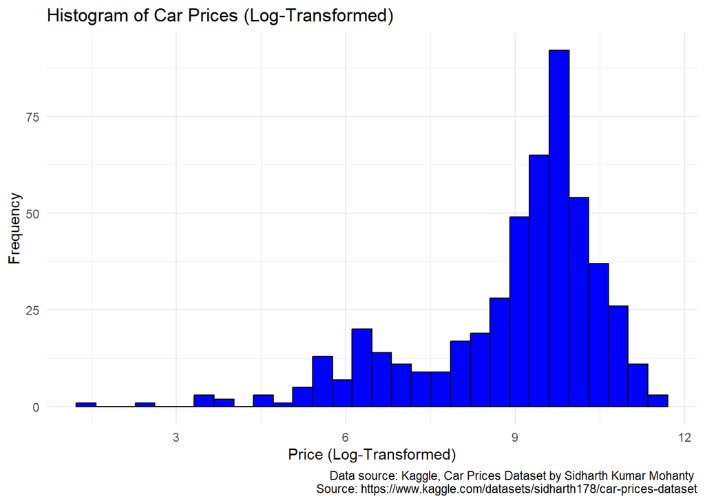

```r
# Apply a logarithmic transformation
 cdf$Log_Price <- log1p(cdf$Price)  # log1p is log(x + 1) to handle zero values

# Plot the histogram of the transformed prices
ggplot(cdf, aes(x = Log_Price)) +
  geom_histogram(bins = 30, fill = "blue", color = "black") +
  labs(title = "Histogram of Car Prices (Log-Transformed)",
       x = "Price (Log-Transformed)",
       y = "Frequency",
       caption = "Data source: Kaggle, Car Prices Dataset by Sidharth Kumar Mohanty \nSource: https://www.kaggle.com/datasets/sidharth178/car-prices-dataset") +

  theme_minimal()
```

## Plot 2 – Apply Grouped Histograms & Discuss Insights

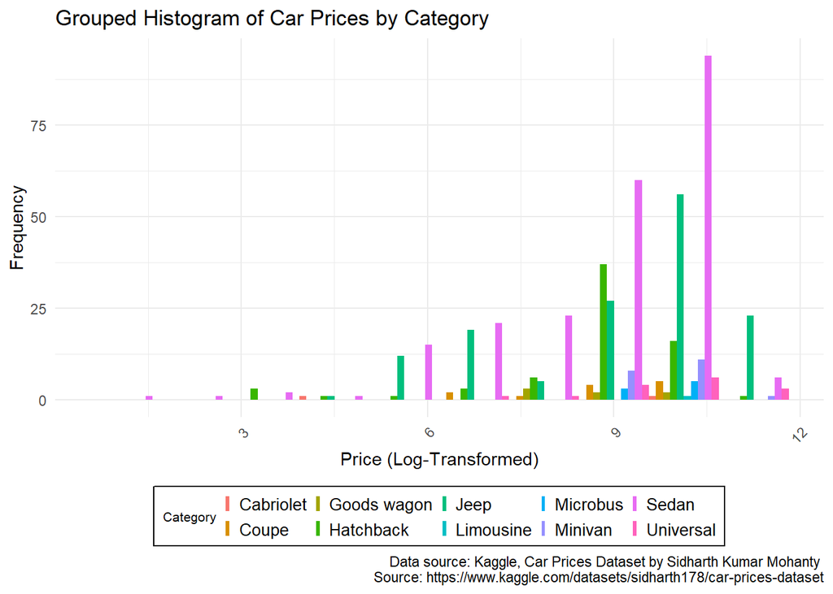

```r
ggplot(cdf, aes(x = Log_Price, fill = Category)) +
  geom_histogram(position = "dodge", bins = 10) +
  labs(title = "Grouped Histogram of Car Prices by Category",
       x = "Price (Log-Transformed)",
       y = "Frequency",
       caption = "Data source: Kaggle, Car Prices Dataset by Sidharth Kumar Mohanty \nSource: https://www.kaggle.com/datasets/sidharth178/car-prices-dataset") +
  theme_minimal() +
  theme(axis.text.x = element_text(angle = 45, hjust = 1),
        legend.position = "bottom", # Moves the legend to the bottom
        legend.title = element_text(size = 8),
        legend.text = element_text(size = 10),
        legend.key.size = unit(0.1, "cm"),
        legend.background = element_rect(fill = "white", size = 0.5, linetype = "solid"))
```

## Plot 3 – Add a Rug Plot in Plot 2 and Deal with Overlapped Points

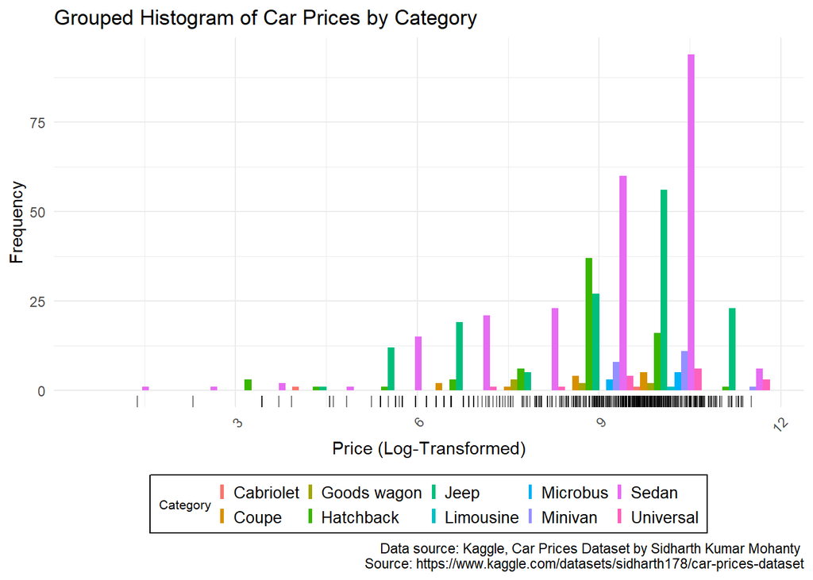

```r
# Generate grouped histograms of Log-Transformed Price by Car Category with a rug plot
ggplot(cdf, aes(x = Log_Price, fill = Category)) +
  geom_histogram(position = "dodge", bins = 10) +  # Adjusted bins for better visualization
  geom_rug(color = "black", alpha = 0.5) +  # Adds a rug plot with some transparency
  labs(title = "Grouped Histogram of Car Prices by Category",
       x = "Price (Log-Transformed)",
       y = "Frequency",
       caption = "Data source: Kaggle, Car Prices Dataset by Sidharth Kumar Mohanty \nSource: https://www.kaggle.com/datasets/sidharth178/car-prices-dataset") +
  theme_minimal() +
  theme(axis.text.x = element_text(angle = 45, hjust = 1),  # Improve x-axis label readability
        legend.position = "bottom",  # Moves the legend to the bottom
        legend.title = element_text(size = 8),
        legend.text = element_text(size = 10),
        legend.key.size = unit(0.1, "cm"),
        legend.background = element_rect(fill = "white", size = 0.5, linetype = "solid"))
```

### Dealing with overlapping points

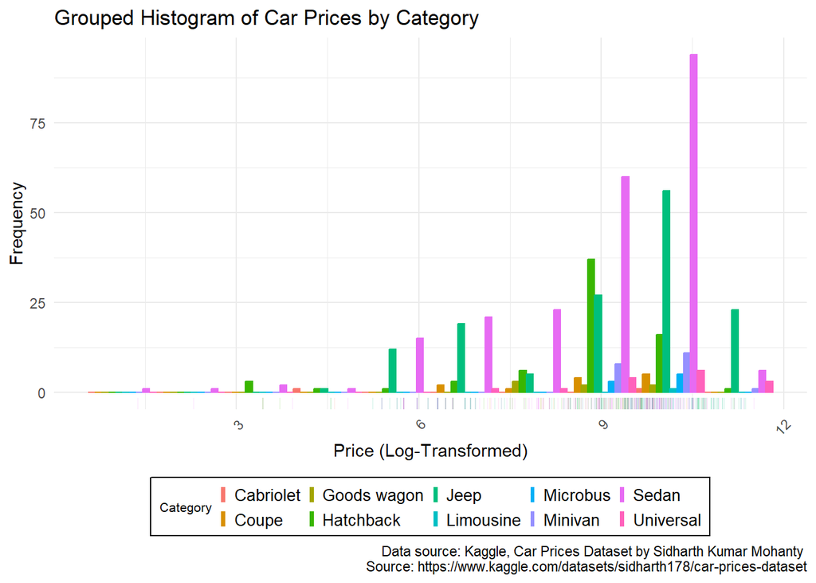

```r
library(ggplot2)

# Generate grouped histograms of Log-Transformed Price by Car Category with a modified rug plot
ggplot(cdf, aes(x = Log_Price, fill = Category, color = Category)) +
  geom_histogram(position = "dodge", bins = 10) +  # Adjusted bins for better visualization
  geom_rug(alpha = 0.1) +  # Using color aesthetics for Category and low alpha for overlap effect
  labs(title = "Grouped Histogram of Car Prices by Category",
       x = "Price (Log-Transformed)",
       y = "Frequency",
       caption = "Data source: Kaggle, Car Prices Dataset by Sidharth Kumar Mohanty \nSource: https://www.kaggle.com/datasets/sidharth178/car-prices-dataset") +
  theme_minimal() +
  theme(axis.text.x = element_text(angle = 45, hjust = 1),  # Improve x-axis label readability
        legend.position = "bottom",  # Moves the legend to the bottom
        legend.title = element_text(size = 8),
        legend.text = element_text(size = 10),
        legend.key.size = unit(0.1, "cm"),
        legend.background = element_rect(fill = "white", size = 0.5, linetype = "solid"))
```

Using colors for overlap in a rug plot is advantageous because it visually conveys the density of data points. When individual data points are represented with varying colors or transparency levels, areas where many points overlap become darker or show blended colors, effectively highlighting regions of high density. This method allows for a clear visual differentiation between sparsely and densely populated areas, making it easier for viewers to identify patterns, trends, and outliers within the dataset. Additionally, it enhances the readability of the plot without overcrowding it, which can happen with simple line overlays, thereby providing a more informative and aesthetically pleasing visualization.

# Task 3: Visualizing Michelson’s Speed-of-Light Measurements

Albert A. Michelson (1882) published estimates of the speed of light obtained through a seminal experiment. The results (in km/s minus 299,000) are stored in R’s built-in morley data frame, which can be loaded into R’s global environment using the following line of code:

```r
data(morley)
morley <- as_tibble(morley)
morley
```

```
# A tibble: 100 × 3
    Expt   Run Speed
   <int> <int> <int>
 1     1     1   850
 2     1     2   740
 3     1     3   900
 4     1     4  1070
 5     1     5   930
 6     1     6   850
 7     1     7   950
 8     1     8   980
 9     1     9   980
10     1    10   880
# ℹ 90 more rows
```

In the Expt column, each measurement is attributed to one of five different experiments. The first 20 measurements belong to experiment 1, the next 20 belong to experiment 2, and so forth. In this exercise, you will visualize these data using various types of graphics, including scatter plot, box plot, violin plot, and facet (one per experiment) plot.

For all the plots, customize the axis labels and add a plot title. Additionally, include a plot caption attributing the source as “R data set `morley`”.

## 3.1 Convert ‘Expt’ Column to Factor

```r
morley <- morley %>%
  mutate(Expt = as.factor(Expt))
```

## 3.2 Plot 1 – Create a Scatter Plot displaying Experiment Number vs. Measured Speeds

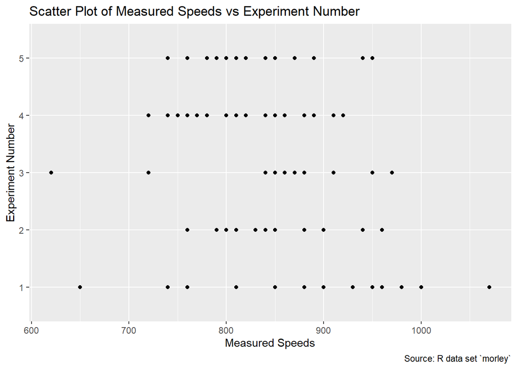

```r
morley %>%
  ggplot(aes(x = Speed, y = Expt)) +
  geom_point() +
  labs(title = "Scatter Plot of Measured Speeds vs Experiment Number",
       y = "Experiment Number",
       x = "Measured Speeds",
       caption = "Source: R data set `morley`")
```

## 3.3 Plot 2 – Create a Box Plot Measured Speeds with One Box Experiment

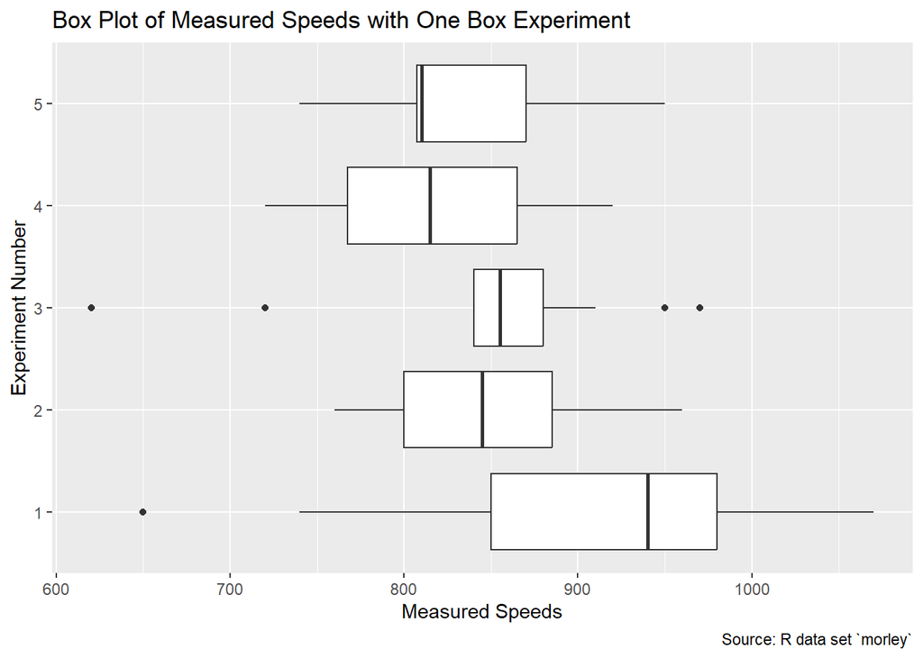

```r
morley %>%
  ggplot(aes(x = Speed, y = Expt)) +
  geom_boxplot() +
  labs(title = "Box Plot of Measured Speeds with One Box Experiment",
       y = "Experiment Number",
       x = "Measured Speeds",
       caption = "Source: R data set `morley`")
```

## 3.4 Plot 3 – Add a Violin Plot in Plot 2

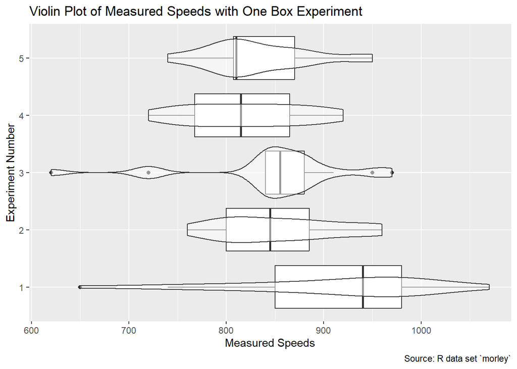

```r
morley %>%
  ggplot(aes(x = Speed, y = Expt)) +
  geom_boxplot() +
  geom_violin(alpha = 0.5) +
  labs(title = "Violin Plot of Measured Speeds with One Box Experiment",
       y = "Experiment Number",
       x = "Measured Speeds",
       caption = "Source: R data set `morley`")
```

## 3.5 Plot 4 – Create a Faceted Plot Containing 5 Histograms

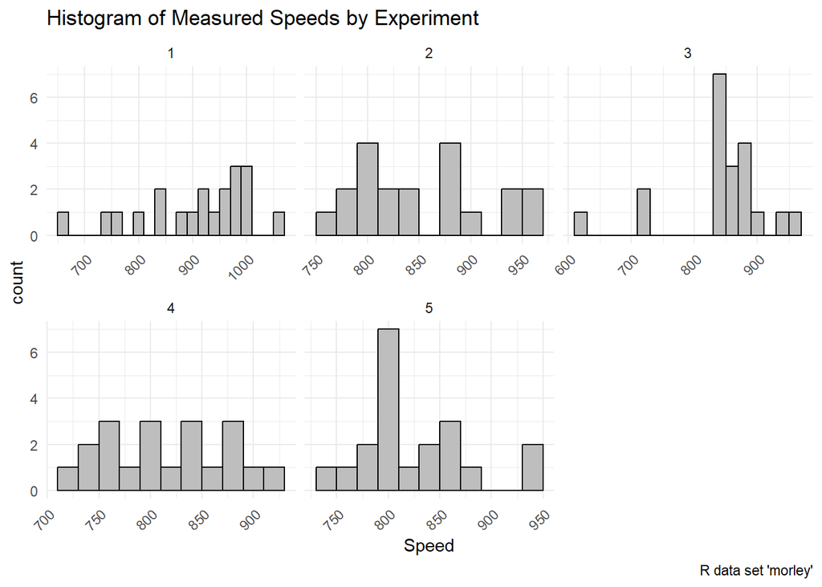

```r
ggplot(morley, aes(x = Speed)) +
  geom_histogram(binwidth = 20, fill = "grey", color = "black") +
  facet_wrap(~Expt, scales = "free_x") +
  labs(title = "Histogram of Measured Speeds by Experiment",
       caption = "R data set 'morley'") +
  theme_minimal() +
  theme(
    axis.text.x = element_text(angle = 45, hjust = 1)
  )
```

## 3.6 Discuss Your Choice Among the 4 Visualization Plots

Scatter Plot (Plot 1):

Purpose: Visualize the relationship between Experiment Number (Expt) and Measured Speeds (Speed). Insights: Helps in understanding if there are any patterns or trends in the measured speeds across different experiments. Useful for initial exploration of data distribution and outliers. Box Plot (Plot 2):

Purpose: Show the distribution of Measured Speeds (Speed) within each Experiment (Expt). Insights: Provides a clear view of the central tendency, spread, and potential outliers in measured speeds for each experiment. Useful for comparing the variability between experiments. Box Plot with Violin Plot Overlay (Plot 3):

Purpose: Enhance the Box Plot by adding a Violin Plot, which shows the density of the distribution. Insights: Combines the insights from the Box Plot with additional information on the distribution shape and density. Useful for a more nuanced understanding of the data distribution within each experiment. Faceted Histograms (Plot 4):

Purpose: Display the distribution of Measured Speeds (Speed) across all experiments, with each experiment shown separately. Insights: Allows for easy comparison of the distribution of speeds across different experiments. Useful for identifying differences or similarities in speed measurements between experiments.

I would choose the violin plot among the 4 plots as it provides a scale of the amount of data distributed in a box plot, along with the usual information provided in a box plot, as the violin plot is a combination of a box plot and a density plot, which provides a better understanding of the data distribution.